# 320 Final Project: Analyzing the Value of NBA Draft Picks

Group members: John Schurman, Eric Zhang, Shaoming Xu

# Introduction

The NBA is one of the biggest sports leagues in the United States, with the average team being worth $2.12 billion as of 2020 (“The Business of Basketball,” 2020). Like many other major league sports, data science and analytics have become an increasingly prevalent tool for teams to try and gain a competitive advantage, and has impacted the way the game is thought about and played, as seen for example by its role in increasing the importance of the 3-point shot (see https://towardsdatascience.com/nba-data-analytics-changing-the-game-a9ad59d1f116). To allow teams to select young new players in a fair manner, an annual draft is held, which has consisted of two rounds (with every team given a pick in the first and second round) since 1989. Any players not selected in those two rounds are allowed to try out and sign with any interested team. More information about the evolution and the current format of the draft can be read here (https://www.nba.com/nba-draft-lottery-explainer). This project is aimed to be an interesting tutorial that introduces the reader to the basic aspects of data science by showing how it can be applied to understanding the value and importance of draft picks within the annual NBA draft. Hopefully, the analysis within here can help the reader gain a sense for the overall “value” players taken at different points in the draft typically add to their team. Understanding this value is vital for teams to evaluate the value of their picks, and consider potential trades of draft picks with other teams to try and get the best value and chance at creating the best team possible.

The dataset we are using can be found at https://www.kaggle.com/justinas/nba-players-data. The data is comprised of individual specific seasons for each NBA player from the 1996-97 to 2016-17 seasons. For this specific project, the important parts of this data that we will be making use of are the statistics it lists for each individual season for a given player, and the information regarding where they were selected in the NBA draft (if they were selected).

# Data Collection and Management

This code reads the locally stored CSV file, then shows the first few rows of output in order to show what the downloaded data looks like unmodified.

```r
library(tidyverse)
library(naniar)
library(ggplot2)
library(gridExtra)

# CSV file downloaded at "https://www.kaggle.com/justinas/nba-players-data"
nba_tab <- read_csv("all_seasons.csv")
head(nba_tab)
```

| X1 | player_name | team_abbreviation | age | player_height | player_weight | college | country | draft_year | draft_round | draft_number | gp | pts | reb | ast | net_rating | oreb_pct | dreb_pct | usg_pct | ts_pct | ast_pct | season |
| --- | --- | --- | --- | --- | --- | --- | --- | --- | --- | --- | --- | --- | --- | --- | --- | --- | --- | --- | --- | --- | --- |
| 0 | Dennis Rodman | CHI | 36 | 198.12 | 99.79024 | Southeastern Oklahoma State | USA | 1986 | 2 | 27 | 55 | 5.7 | 16.1 | 3.1 | 16.1 | 0.186 | 0.323 | 0.100 | 0.479 | 0.113 | 1996-97 |
| 1 | Dwayne Schintzius | LAC | 28 | 215.90 | 117.93392 | Florida | USA | 1990 | 1 | 24 | 15 | 2.3 | 1.5 | 0.3 | 12.3 | 0.078 | 0.151 | 0.175 | 0.430 | 0.048 | 1996-97 |
| 2 | Earl Cureton | TOR | 39 | 205.74 | 95.25432 | Detroit Mercy | USA | 1979 | 3 | 58 | 9 | 0.8 | 1.0 | 0.4 | -2.1 | 0.105 | 0.102 | 0.103 | 0.376 | 0.148 | 1996-97 |
| 3 | Ed O'Bannon | DAL | 24 | 203.20 | 100.69742 | UCLA | USA | 1995 | 1 | 9 | 64 | 3.7 | 2.3 | 0.6 | -8.7 | 0.060 | 0.149 | 0.167 | 0.399 | 0.077 | 1996-97 |
| 4 | Ed Pinckney | MIA | 34 | 205.74 | 108.86208 | Villanova | USA | 1985 | 1 | 10 | 27 | 2.4 | 2.4 | 0.2 | -11.2 | 0.109 | 0.179 | 0.127 | 0.611 | 0.040 | 1996-97 |
| 5 | Eddie Johnson | HOU | 38 | 200.66 | 97.52228 | Illinois | USA | 1981 | 2 | 29 | 52 | 8.2 | 2.7 | 1.0 | 4.1 | 0.034 | 0.126 | 0.220 | 0.541 | 0.102 | 1996-97 |

## Cleaning data

Data processing is one of the most important steps to analyse data. Load the data into dataframe with appropriate names that it can accurately describe the data. After loading the data, we now create a tidier data table with some characteristics changed in order to set it up for analysis later. We create a new column called ‘undrafted’ that is true if that player was undrafted, and false if not. We then replace entries that had “undrafted” listed as their draft_year, draft_round, and draft_number with ‘NA’ instead. We convert the draft_round, draft_year, and draft_number columns to be integers instead of characters. You should learn to get rid of missing data appropriately before doing any actual analysis to avoid any unnecessary errors. Additionally, since the NBA switched to a 2-round draft in 1989, to accurately measure the value of draft picks in the modern draft format, we’re going to filter out any players who were drafted before 1989. We also exclude erroneous entries that have draft_round listed as greater than 2.

```r
tidy_nba <-
  nba_tab %>%
mutate(Undrafted = ifelse(draft_round == "Undrafted" | draft_year == "Undrafted" |
                        draft_number == "Undrafted",TRUE,FALSE)) %>%
  replace_with_na_all(condition = ~.x == "Undrafted")


# Converts the data type
tidy_nba$draft_round <- as.integer(tidy_nba$draft_round)
tidy_nba$draft_year <- as.integer(tidy_nba$draft_year)
tidy_nba$draft_number <- as.integer(tidy_nba$draft_number)

tidy_nba <-
  filter(tidy_nba, (draft_year >= 1989 | is.na(draft_year)) &
           (draft_round <= 2 | is.na(draft_round)))

head(tidy_nba)
```

| X1 | player_name | team_abbreviation | age | player_height | player_weight | college | country | draft_year | draft_round | draft_number | gp | pts | reb | ast | net_rating | oreb_pct | dreb_pct | usg_pct | ts_pct | ast_pct | season | Undrafted |
| --- | --- | --- | --- | --- | --- | --- | --- | --- | --- | --- | --- | --- | --- | --- | --- | --- | --- | --- | --- | --- | --- | --- |
| 1 | Dwayne Schintzius | LAC | 28 | 215.90 | 117.93392 | Florida | USA | 1990 | 1 | 24 | 15 | 2.3 | 1.5 | 0.3 | 12.3 | 0.078 | 0.151 | 0.175 | 0.430 | 0.048 | 1996-97 | FALSE |
| 3 | Ed O'Bannon | DAL | 24 | 203.20 | 100.69742 | UCLA | USA | 1995 | 1 | 9 | 64 | 3.7 | 2.3 | 0.6 | -8.7 | 0.060 | 0.149 | 0.167 | 0.399 | 0.077 | 1996-97 | FALSE |
| 6 | Eddie Jones | LAL | 25 | 198.12 | 86.18248 | Temple | USA | 1994 | 1 | 10 | 80 | 17.2 | 4.1 | 3.4 | 4.1 | 0.035 | 0.091 | 0.209 | 0.559 | 0.149 | 1996-97 | FALSE |
| 7 | Elden Campbell | LAL | 28 | 213.36 | 113.39800 | Clemson | USA | 1990 | 1 | 27 | 77 | 14.9 | 8.0 | 1.6 | 3.3 | 0.095 | 0.183 | 0.222 | 0.520 | 0.087 | 1996-97 | FALSE |
| 8 | Eldridge Recasner | ATL | 29 | 193.04 | 86.18248 | Washington | USA | 1992 | NA | NA | 71 | 5.7 | 1.6 | 1.3 | -0.3 | 0.036 | 0.076 | 0.172 | 0.539 | 0.141 | 1996-97 | TRUE |
| 9 | Elliot Perry | MIL | 28 | 182.88 | 72.57472 | Memphis | USA | 1991 | 2 | 37 | 82 | 6.9 | 1.5 | 3.0 | -1.2 | 0.018 | 0.081 | 0.177 | 0.557 | 0.262 | 1996-97 | FALSE |

This code creates a dataframe that only includes players in their rookie seasons. The first season this dataset has data from is the 1996-1997 season. Some players who played in the 1996 had been drafted before that year, and because undrafted players do not have a draft_year listed and so it cannot be determined whether 1996 was their first season or not, we’re only looking at all rookie seasons starting from 1997 instead. To accomplish this, we make use of the distinct function, which removes all duplicate entries based on the provided variable (in this case, player_name). To get this to have the intended result, we use the fact that the tidy_nba data frame is sorted by season in ascending order. If the data frame wasn’t already in the desired order, you can use the arrange function with a provided variable to order it.

```r
# remove entries with duplicate names, then use filter to get rid of the 1996
# season
rookie_after_1997_df <-
  tidy_nba %>%
  distinct(player_name, .keep_all = TRUE) %>%
  filter(season != "1996-97")

rookie_after_1997_df
```

| X1 | player_name | team_abbreviation | age | player_height | player_weight | college | country | draft_year | draft_round | draft_number | gp | pts | reb | ast | net_rating | oreb_pct | dreb_pct | usg_pct | ts_pct | ast_pct | season | Undrafted |
| --- | --- | --- | --- | --- | --- | --- | --- | --- | --- | --- | --- | --- | --- | --- | --- | --- | --- | --- | --- | --- | --- | --- |
| 442 | Marko Milic | PHX | 21 | 198.12 | 106.59412 | None | Slovenia | 1997 | 2 | 33 | 33 | 2.8 | 0.8 | 0.4 | 7.4 | 0.076 | 0.099 | 0.245 | 0.644 | 0.113 | 1997-98 | FALSE |
| 448 | Maurice Taylor | LAC | 21 | 205.74 | 117.93392 | Michigan | USA | 1997 | 1 | 14 | 71 | 11.5 | 4.2 | 0.7 | -9.5 | 0.089 | 0.136 | 0.262 | 0.521 | 0.069 | 1997-98 | FALSE |
| 458 | Mario Bennett | LAL | 24 | 205.74 | 106.59412 | Arizona State | USA | 1995 | 1 | 27 | 45 | 3.9 | 2.8 | 0.4 | 5.0 | 0.164 | 0.207 | 0.201 | 0.573 | 0.084 | 1997-98 | FALSE |
| 464 | Mark Pope | IND | 25 | 208.28 | 106.59412 | Kentucky | USA | 1996 | 2 | 52 | 28 | 1.4 | 0.9 | 0.3 | -0.2 | 0.056 | 0.115 | 0.145 | 0.402 | 0.062 | 1997-98 | FALSE |
| 489 | Michael Stewart | SAC | 23 | 208.28 | 104.32616 | California | USA | NA | NA | NA | 81 | 4.6 | 6.6 | 0.8 | -3.0 | 0.125 | 0.211 | 0.120 | 0.486 | 0.054 | 1997-98 | TRUE |
| 491 | Michael McDonald | CHH | 29 | 208.28 | 105.23334 | New Orleans | USA | 1995 | 2 | 55 | 1 | 0.0 | 1.0 | 0.0 | -71.4 | 0.250 | 0.000 | 0.250 | 0.000 | 0.000 | 1997-98 | FALSE |
| 497 | Kebu Stewart | PHI | 24 | 203.20 | 108.40849 | Cal State-Bakersfield | USA | 1997 | 2 | 35 | 15 | 2.7 | 2.1 | 0.1 | 11.7 | 0.087 | 0.212 | 0.173 | 0.541 | 0.030 | 1997-98 | FALSE |
| 502 | Johnny Taylor | ORL | 24 | 205.74 | 99.79024 | Tennessee-Chattanooga | USA | 1997 | 1 | 17 | 12 | 3.2 | 1.1 | 0.1 | 4.8 | 0.043 | 0.127 | 0.215 | 0.431 | 0.014 | 1997-98 | FALSE |
| 505 | John Thomas | TOR | 22 | 205.74 | 120.20188 | Minnesota | USA | 1997 | 1 | 25 | 54 | 2.8 | 2.0 | 0.3 | -2.6 | 0.099 | 0.133 | 0.145 | 0.552 | 0.050 | 1997-98 | FALSE |
| 519 | Keith Booth | CHI | 23 | 198.12 | 102.51179 | Maryland | USA | 1997 | 1 | 28 | 6 | 1.7 | 0.7 | 0.2 | -10.0 | 0.100 | 0.125 | 0.236 | 0.579 | 0.077 | 1997-98 | FALSE |

[output cut: 1774 more lines]

We have 20 attributes for each entity(which is basketball player) and the definition of each attributes are listed below(): (1)player_name: name of the players and there are 2235 unique values. (2)team_abbreviation:Abbreviated name of the team the player played for (at the end of the season) (3)age: Age of the player (4)player_height: Height of the player (in centimeters) (5)player_weight: Weight of the player (in kilograms) (6)college: Name of the college the player attended (7)country：Name of the country the player was born in (not necessarily the nationality) (8)draft_year: The year the player was drafted (9)draft_round: The draft round the player was picked (10)draft_number: The number at which the player was picked in his draft round (11)gp: Games played throughout the season (12)pts: Average number of points scored (13)reb: Average number of rebounds grabbed (14)ast: Average number of assists distributed (15)net_rating: Team’s point differential per 100 possessions while the player is on the court (16)oreb_pct: Percentage of available offensive rebounds the player grabbed while he was on the floor (17)dreb_pct: Percentage of available defensive rebounds the player grabbed while he was on the floor (18)usg_pct: Percentage of team plays used by the player while he was on the floor (FGA + Possession Ending FTA + TO) / POSS) (19)ts_pct: Measure of the player’s shooting efficiency that takes into account free throws, 2 and 3 point shots (PTS / (2*(FGA + 0.44* FTA))) (20)ast_pct: Percentage of teammate field goals the player assisted while he was on the floor

For more information about these and other advanced statistics in the NBA, consult https://stats.nba.com/help/glossary/

# Exploratory Data Analysis and Visualization

## Rookie Stats

Grouping all the rookie seasons by their draft pick to show the averages for all playing statistics (games played, points, etc.) by players chosen with that pick in their rookie season.

```r
rookie_performance_by_pick_df <-
rookie_after_1997_df %>%
  group_by(draft_number) %>%
  summarize_at(vars(gp:ast_pct), list(mean = mean))

rookie_performance_by_pick_df
```

| draft_number | gp_mean | pts_mean | reb_mean | ast_mean | net_rating_mean | oreb_pct_mean | dreb_pct_mean | usg_pct_mean | ts_pct_mean | ast_pct_mean |
| --- | --- | --- | --- | --- | --- | --- | --- | --- | --- | --- |
| 1 | 66.56522 | 14.469565 | 7.008696 | 2.8347826 | -2.2260870 | 0.08065217 | 0.1834783 | 0.2255652 | 0.5313478 | 0.14934783 |
| 2 | 67.43478 | 11.265217 | 4.800000 | 2.4826087 | -5.3173913 | 0.06147826 | 0.1519565 | 0.2103043 | 0.5060435 | 0.13813043 |
| 3 | 68.86957 | 12.247826 | 4.795652 | 2.1347826 | -3.1130435 | 0.05869565 | 0.1471304 | 0.2189565 | 0.5228261 | 0.13552174 |
| 4 | 65.78261 | 10.769565 | 4.604348 | 2.3956522 | -5.7086957 | 0.06108696 | 0.1453043 | 0.2097826 | 0.5028261 | 0.13886957 |
| 5 | 69.50000 | 9.312500 | 3.875000 | 2.5208333 | -4.3458333 | 0.05791667 | 0.1376667 | 0.1999583 | 0.4934583 | 0.15187500 |
| 6 | 64.43478 | 9.421739 | 3.943478 | 1.8956522 | -4.7826087 | 0.05639130 | 0.1284783 | 0.1807826 | 0.5192174 | 0.10943478 |
| 7 | 68.65217 | 10.508696 | 4.260870 | 2.2478261 | -7.8956522 | 0.04886957 | 0.1316087 | 0.1988261 | 0.5015652 | 0.12469565 |
| 8 | 61.00000 | 6.837500 | 2.916667 | 1.5708333 | -3.8291667 | 0.05712500 | 0.1285000 | 0.1861667 | 0.4866667 | 0.11883333 |
| 9 | 58.08696 | 8.095652 | 3.973913 | 1.5956522 | -3.6652174 | 0.07230435 | 0.1561739 | 0.1904348 | 0.5112609 | 0.11095652 |
| 10 | 63.95652 | 7.913043 | 3.286957 | 1.8608696 | -5.0826087 | 0.04973913 | 0.1293913 | 0.1930000 | 0.4947826 | 0.12865217 |

[output cut: 51 more lines]

I want to show the relationship between the number of drafts with average points of players. First, I remove the NA(undrafted) player from the list and use linear regression to find the correlation. By using linear regression, it is clearly in the graph that the number of drafts has a negative relationship with average points, which means that the player with lower draft numbers seems to play better than the player with high draft numbers.

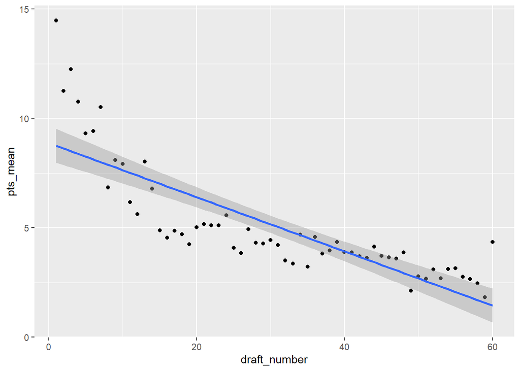

```r
rookie_performance_by_pick_df<-na.omit(rookie_performance_by_pick_df)
rookie_performance_by_pick_df%>%ggplot(aes(x=draft_number,y=pts_mean))+geom_point()+geom_smooth(method=lm)
```

## Visualizing Performance Metrics

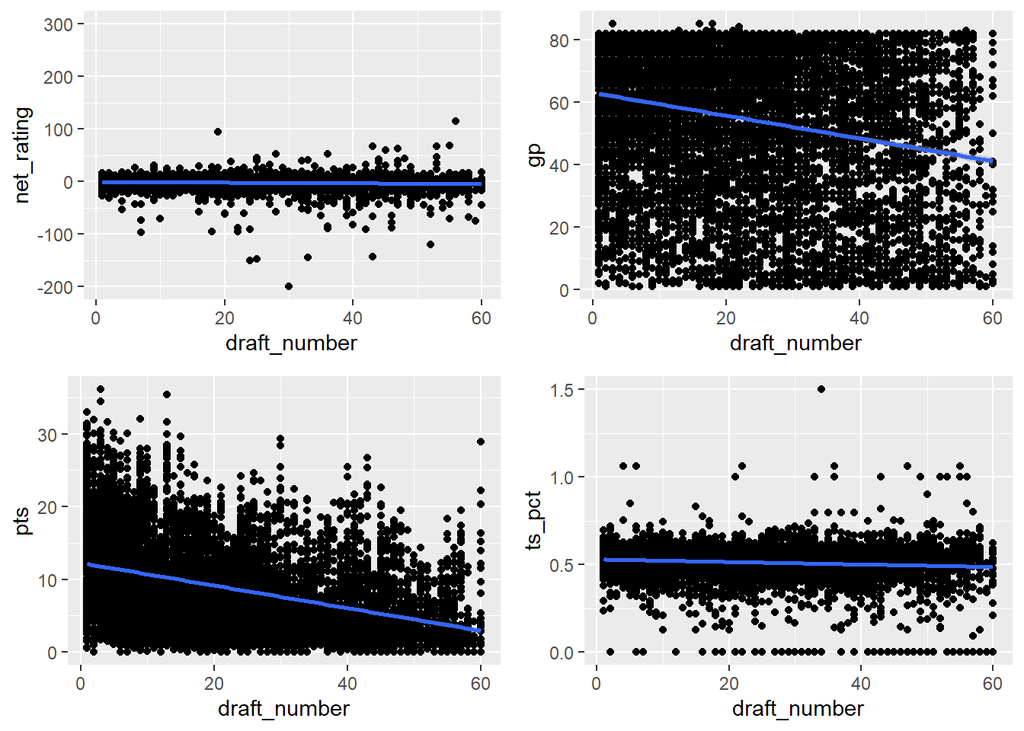

```r
p1 <- tidy_nba %>%
  ggplot(aes(x=draft_number, y=net_rating)) +
  geom_point()+geom_smooth(method=lm)
p2 <- tidy_nba %>%
  ggplot(aes(x=draft_number, y=gp)) +
  geom_point()+geom_smooth(method=lm)
p3 <- tidy_nba %>%
  ggplot(aes(x=draft_number, y=pts)) +
  geom_point()+geom_smooth(method=lm)
p4 <- tidy_nba %>%
  ggplot(aes(x=draft_number, y=ts_pct)) +
  geom_point()+geom_smooth(method=lm)
grid.arrange(p1,p2,p3,p4, nrow = 2)
```

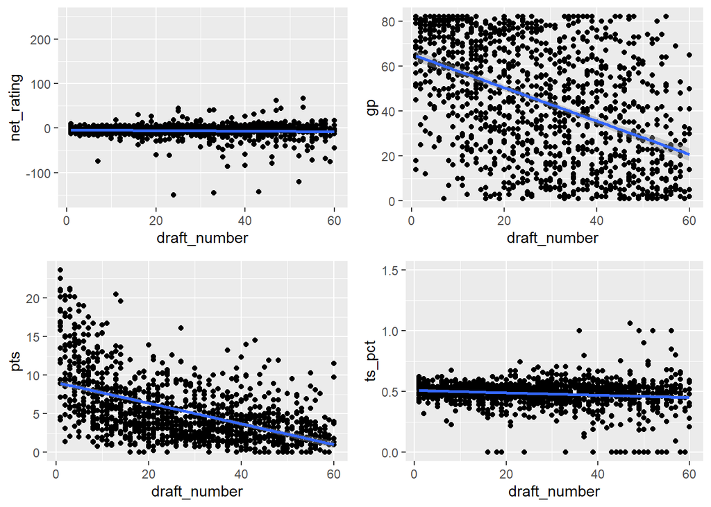

```r
p1 <- rookie_after_1997_df %>%
  ggplot(aes(x=draft_number, y=net_rating)) +
  geom_point()+geom_smooth(method=lm)
p2 <- rookie_after_1997_df %>%
  ggplot(aes(x=draft_number, y=gp)) +
  geom_point()+geom_smooth(method=lm)
p3 <- rookie_after_1997_df %>%
  ggplot(aes(x=draft_number, y=pts)) +
  geom_point()+geom_smooth(method=lm)
p4 <- rookie_after_1997_df %>%
  ggplot(aes(x=draft_number, y=ts_pct)) +
  geom_point()+geom_smooth(method=lm)
grid.arrange(p1, p2,p3,p4, nrow = 2)
```

Here, we are trying to show the relationship between draft numbers with other statistics performance. (1)The scatter plot of draft_number with net_rating and the draft_number with ts_pct, it seems like that there is no correlation between draft number with net rating and ts_pct because the change of draft number do not change whether net_ranking or ts_pct (2)For the scatter plots of draft numbers with gp(game played), we can not directly tell the relationship. A regression line can be a perfect tool to solve this. (More tutorial resource about regression line:https://www.theanalysisfactor.com/linear-models-r-plotting-regression-lines/) It is clearly that players who have less draft number played more than the players who have more.So, it is a negative relationship between game_played with draft_number. (3) For the scatter plot of pts and draft number, the slope of the regression line is negative so that there is a negative relationship between those two. It means that the players which have less draft number(they have been picked first in the draft pick) can get more points in the game. (4)The last four scatter plots are based on the data frame which only focus on the rookie player. The result is similar with what we have before.

Unfortunately we’re missing information about the undrafted players as they don’t contain a draft number and are not plotted. Here we conduct a single variable visualization with density plots to compare between drafted and undrafted respectively. Density plots are useful to see the spread of data; they’re essentially smoothed out histograms.

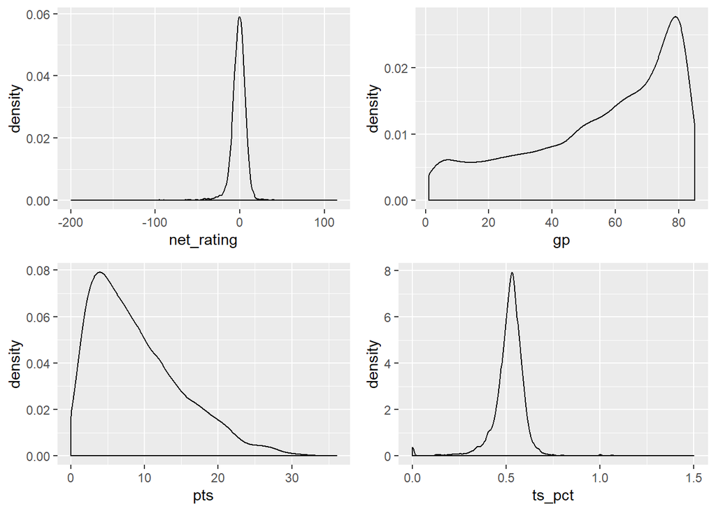

```r
undrafted_df <- tidy_nba %>%
  filter(is.na(draft_number))
drafted_df <- tidy_nba %>%
  na.omit()

p1 <- drafted_df %>%
  ggplot(aes(x=net_rating)) +
  geom_density()
p2 <- drafted_df %>%
  ggplot(aes(x=gp)) +
  geom_density()
p3 <- drafted_df %>%
  ggplot(aes(x=pts)) +
  geom_density()
p4 <- drafted_df %>%
  ggplot(aes(x=ts_pct)) +
  geom_density()
grid.arrange(p1, p2,p3,p4, nrow = 2)
```

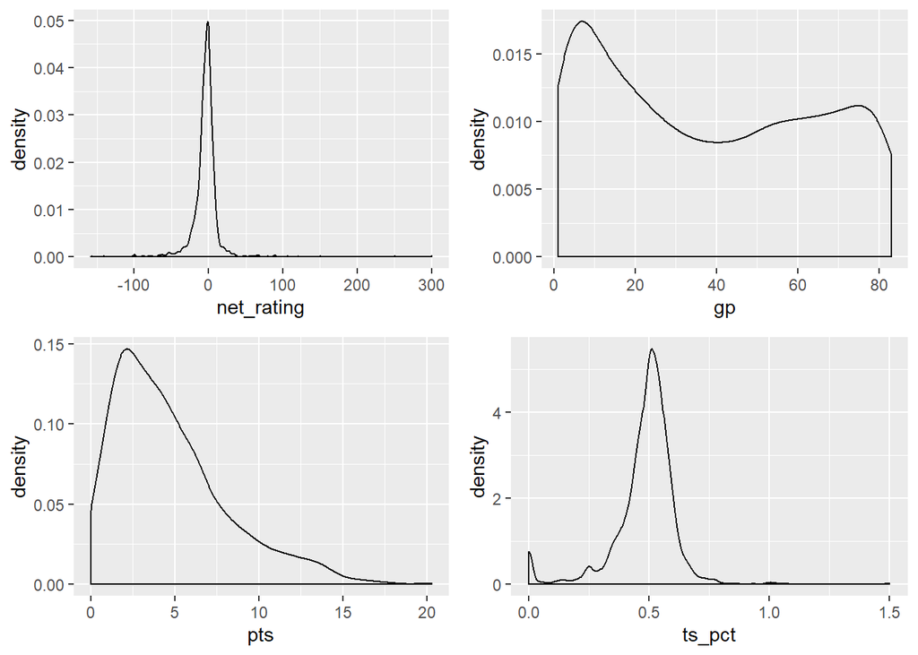

```r
p1 <- undrafted_df %>%
  ggplot(aes(x=net_rating)) +
  geom_density()
p2 <- undrafted_df %>%
  ggplot(aes(x=gp)) +
  geom_density()
p3 <- undrafted_df %>%
  ggplot(aes(x=pts)) +
  geom_density()
p4 <- undrafted_df %>%
  ggplot(aes(x=ts_pct)) +
  geom_density()

grid.arrange(p1, p2,p3,p4, nrow = 2)
```

We can see that the spreads are generally similar unimodal distributions except for undrafted games played. Where the undrafted model has a bimodal distribution. The majority of drafted players seem to have high games played while undrafted players are more spread out. In addition, drafted players score much more points, the tail extending past 30, whereas the tail ends around 20 for undrafted players. Drafted players also perform better in their total shot percentage; though the center is about the same, the density of players is much higher. The density of lower shot percentages is higher for undrafted players.

## Draft Pick Distribution

Now we will make a pie chart to show the percentage of players taken in what set of picks make up the NBA player base during the 2016-17 season. Trying to assign a percentage for each of the 60 picks in the draft would divide the data into a lot of small ranges without many data points, but simply dividing it up into the 1st round, 2nd round, and undrafted might not be as informative and precise as we would like, especially since previous data analysis has shown that there seems to be a big difference between players chosen at the beginning of the first round and towards the end of the second round specifically. When you run into this problem in data science where you want to group some entities together into groups depending on the value of some attribute, you can use what is called discretization (although draft_number is already a discrete variable here). This is usually used to transform continuous values into discrete values, and typically either places values into a specified number of intervals regardless of how many values fit into each one, or places an equal number of values into each interval, with the range of the intervals varying to match the distribution. To learn more about when to use discretization and how different ways to implement it, you can read (the article here)[https://towardsdatascience.com/an-introduction-to-discretization-in-data-science-55ef8c9775a2]

In R, discretization can be implemented using the cut function, as seen below. We use it here to divide the draft_number attribute into 6 intervals, with each interval containing 10 draft picks, then label the intervals with the inclusive range of picks they represent. First we make a pie chart representing all the players who played during the season, then we make another pie chart where all the rookies are excluded. Doing this should allow us to gain a better understanding of what draft picks usually turn out good enough to stay in the league to better understand player retention. It uses geom_bar() and coord_polar() from the [ggplot2 package](https://github.com/rstudio/cheatsheets/blob/master/data-visualization-2.1.pdf) to make the pie charts.

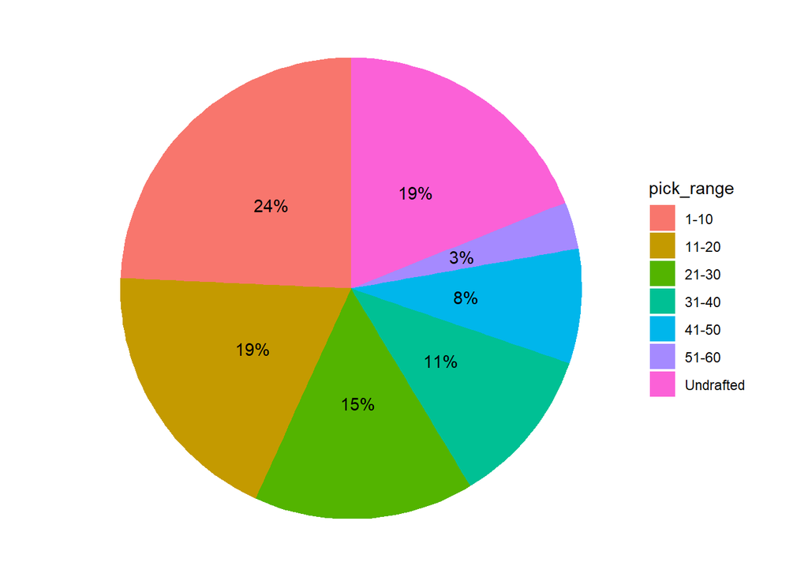

```r
# the breaks argument in cut() breaks the draft_number values into 6 distinct
# ranges, with the first number being an exclusive lower bound and the next
# being the inclusive upper bound as well as the exclusive lower bound for the
# next range, and so on.
discrete_picks_df <-
  tidy_nba %>%
  mutate(pick_range = cut(draft_number, breaks = c(0, 10, 20, 30, 40, 50, 60),
                             labels = c("1-10", "11-20", "21-30", "31-40", "41-50", "51-60")))

# Make the pick_range column be characters instead, then assign any entry
# that was undrafted the value of "Undrafted" for better naming purposes
discrete_picks_df$pick_range <- as.character(discrete_picks_df$pick_range)
discrete_picks_df$pick_range[is.na(discrete_picks_df$pick_range)] <- "Undrafted"

# Creates data frame that takes all the entries of players from the 2016-17
# season and counts how many players fell into which discretized range of draft
# picks. It then calculates what percentage of all players fell into which group
# that season.
season_discr_pick_percent_df <-
  filter(discrete_picks_df, season == "2016-17") %>%
  group_by(pick_range) %>%
  count() %>%
  ungroup() %>%
  mutate(range_percentage = n/sum(n)) %>%
  arrange(desc(pick_range))

# Creates the pie chart based on the data frame created above. subtracting half
# of the percentage from the y value helps ggplot optimize the position of the
# label on the chart.
ggplot(season_discr_pick_percent_df) +
  geom_bar(aes(x = "", y = range_percentage, fill = pick_range), stat = "identity", width = 1) +
  coord_polar(theta = "y", start = 0) +
  theme_void() +
  geom_text(aes(x = 1, y = cumsum(range_percentage) - (range_percentage/2),
                label = scales::percent(range_percentage)))
```

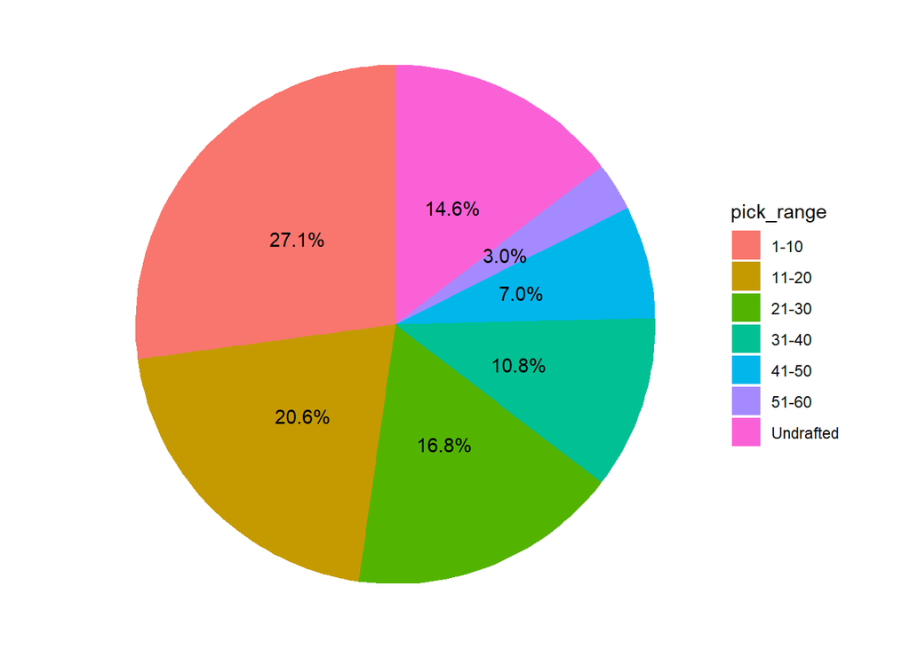

```r
# Create a dataframe similar to season_discr_pick_percent_df, but without any
# rookies. anti_join() does this by removing any players from the filtered
# discrete_picks_df for the 2016-17 season who appear on the list of rookies
# with the same name and their rookie season matching 2016-17. The rest is the
# same as before.
season_discr_pick_percent_nonrookies <-
  filter(discrete_picks_df, season == "2016-17") %>%
  anti_join(rookie_after_1997_df, by = c("player_name", "season")) %>%
  group_by(pick_range) %>%
  count() %>%
  ungroup() %>%
  mutate(range_percentage = n/sum(n)) %>%
  arrange(desc(pick_range))

# Use the same process as the previous pie chart to make the new one without any
# rookies.
ggplot(season_discr_pick_percent_nonrookies) +
  geom_bar(aes(x = "", y = range_percentage, fill = pick_range), stat = "identity", width = 1) +
  coord_polar(theta = "y", start = 0) +
  theme_void() +
  geom_text(aes(x = 1, y = cumsum(range_percentage) - (range_percentage/2),
                label = scales::percent(range_percentage)))
```

Based on the pie charts, Players picked within the top ten picks made up almost a quarter of all players in the league in 2016, with each subsequent interval of ten picks making up about 3-5% less of the league than the previous interval. Somewhat surprisingly, 19% of the league consisted of undrafted players. However, this makes more sense considering that the NBA has 30 teams, each with a maximum roster of 15 players, with additional players needing to join teams when players get injured (“NBA Frequently Asked Questions,” 2019). This results in a minimum of 450 players making a roster in 2016, with only 60 rookies getting drafted, so a sizeable amount of undrafted rookies are needed to fill out rosters. By comparing the two pie charts, you can better see how many rookies do not pan out. As a percent of all the NBA players playing in at least their second season in 2016, the proportion of top ten picks went up by 3%. The proportion for every interval of picks in the first round increased, whereas every interval of players drafted in the 2nd or who went undrafted decreased or stayed the same, indicating a higher turnover rate of players within those intervals. The proportion of undrafted players went from 19% to 14.6%, indicating an especially high rate of undrafted players not making it to their second season. It’s also interesting to note that over 60% of the players playing in at least their second NBA season were drafted in the first round.

To try and get a better understanding of the impact the players picked in the different pick intervals have on the court, we can summarize and compare their net ratings (an advanced statistic described earlier which tries to capture a players offensive and defensive contributions). We will also filter out players who haven’t played in more than 10 games to ensure a player’s rating isn’t skewed by limited playing time.

```r
season_discr_pick_net_rating <-
  filter(discrete_picks_df, gp >= 10) %>%
  group_by(pick_range) %>%
  summarize(mean_net_rating=mean(net_rating)) %>%
  arrange(desc(pick_range))
season_discr_pick_net_rating
```

| pick_range | mean_net_rating |
| --- | --- |
| Undrafted | -2.9076824 |
| 51-60 | -1.8019391 |
| 41-50 | -1.9669221 |
| 31-40 | -2.3509664 |
| 21-30 | -1.3182957 |
| 11-20 | -1.6347200 |
| 1-10 | -0.3701264 |

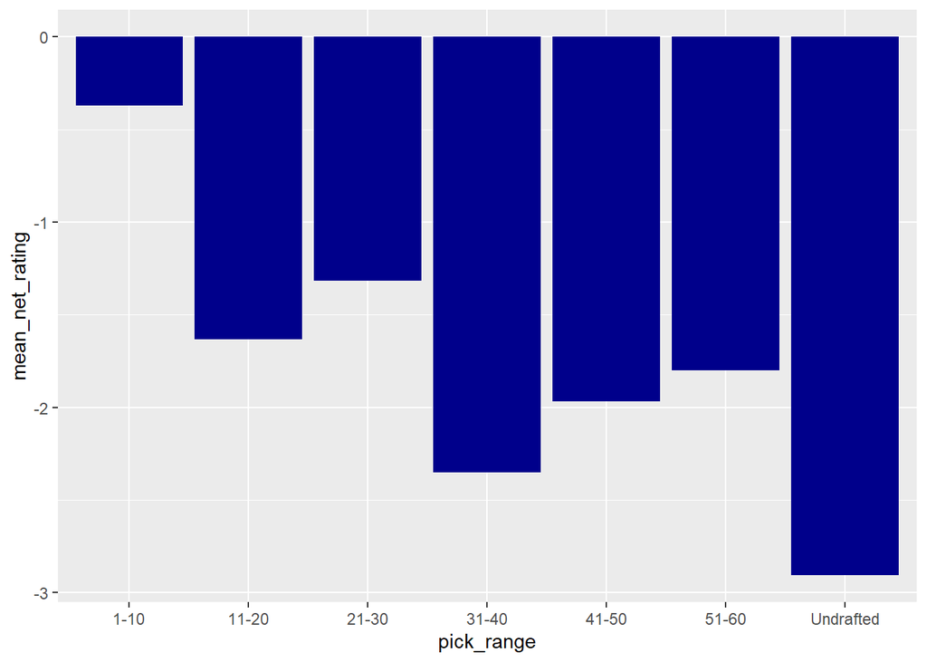

```r
# bar graph comparing the net ratings of the intervals
season_discr_pick_net_rating %>%
  ggplot(aes(x=pick_range, y=mean_net_rating)) +
  geom_bar(stat="identity", fill="darkblue")
```